# PML Project

Friday, September 19, 2014

### Introduction

Scope of the project is building a model capable of predicting the execution quality of a barbell lift exercise, given a set of measurements from sensors worn by a group of volunteers.

```r
library(caret);library(kernlab);library(ggplot2)
set.seed(1978)
```

The project is carried out mainly using the caret package.

### The Data

The data set “pml-training” is provided to build this model. It contains 19622 observations, 160 variables.

#### The quality of the data, clean-up

By analyzing the provided data set, it emerges that it needs to be cleaned up to be used.

1. The first step was removing the columns containing mainly NotAvailable’s (NA), no values at all or not processable data (like div by 0). Scanning the data set, it turns out that the offenders are all the variables whose names begin with: avg_, kurtosis_, stddev_, var_, skewness_, min_, max_, amplitude_.
2. Additionally, the first 7 columns contain apparently non relevant data for our scopes (observation n.,name of the volunteer, time infos, time window n.). Because of that, they are also removed from the data set.

```r
data <- read.csv("pml-training.csv")

dataRed<-data[,which(!grepl('avg',colnames(data)))]
dataRed<-dataRed[,which(!grepl('kurtosis',colnames(dataRed)))]
dataRed<-dataRed[,which(!grepl('stddev',colnames(dataRed)))]
dataRed<-dataRed[,which(!grepl('var',colnames(dataRed)))]
dataRed<-dataRed[,which(!grepl('skewness',colnames(dataRed)))]
dataRed<-dataRed[,which(!grepl('min',colnames(dataRed)))]
dataRed<-dataRed[,which(!grepl('max',colnames(dataRed)))]
dataRed<-dataRed[,which(!grepl('amplitude',colnames(dataRed)))]
dataRed<-dataRed[,-c(1:7)]
```

This reduces the number of actual variables to 53 (52 predictors + 1 “classe” variable).

### Cross validation and pre-processing:

```r
inTrain <- createDataPartition(y=dataRed$classe,p=0.01,list=FALSE)
training <- dataRed[inTrain,]
testing<-dataRed[-inTrain,]
```

The training set will be used to train the model and to obtain the first relevant matrics about its performance (like the error and the accuracy).

The test set will be used to test the model, obtaining a more plausible indication of its performance, as it will be estimated using “unknown” data (i.e. not used, implicitely or explicitely to build the model).

### The model

The available predictors are all continuous variables, while the outcome is a categorical one. This leads to use classification algorithms; among them, I chose the the random forest, mainly because of its high level of accuracy.

Concerning the **pre processing**, although some variables are characterized by significantly skewed distributions, some tests I carried out did not show any increase of accuracy by adopting, for example, a centering and scaling approach.

```r
modFit=train(classe ~ .,method = "rf",data=training)
```

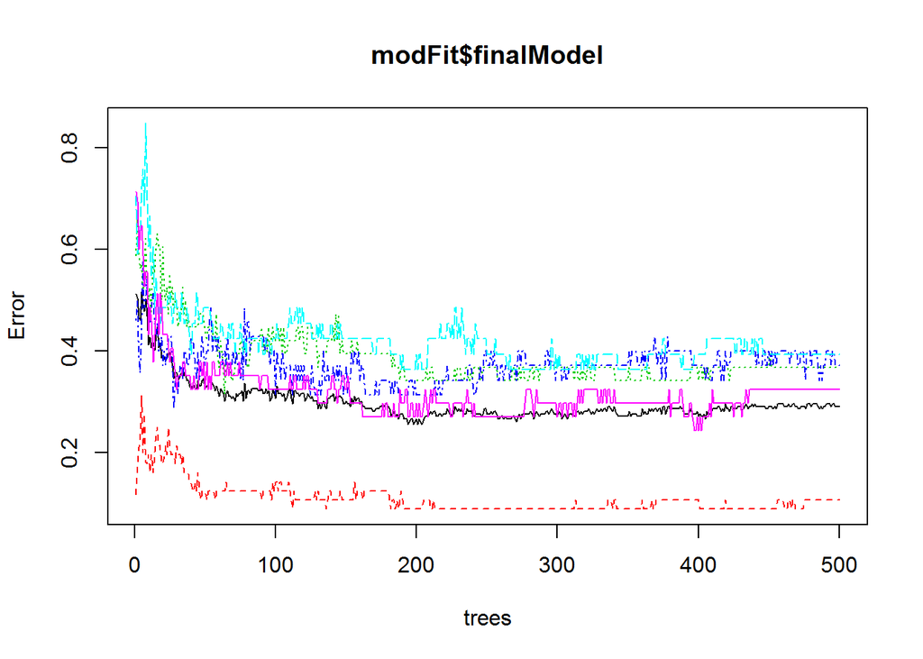

```r
plot(modFit$finalModel)
```

```r
modFit
```

```
## Random Forest
##
## 199 samples
##  52 predictor
##   5 classes: 'A', 'B', 'C', 'D', 'E'
##
## No pre-processing
## Resampling: Bootstrapped (25 reps)
##
## Summary of sample sizes: 199, 199, 199, 199, 199, 199, ...
##
## Resampling results across tuning parameters:
##
##   mtry  Accuracy  Kappa  Accuracy SD  Kappa SD
##    2    0.7       0.6    0.05         0.06
##   27    0.7       0.6    0.05         0.07
##   52    0.7       0.6    0.05         0.07
##
## Accuracy was used to select the optimal model using  the largest value.
## The final value used for the model was mtry = 2.
```

Applying the model to the testing data set and comparing its predictions to the actual values, we obtain:

```r
OS_prediction <- predict(modFit,testing)
C_matrix <- confusionMatrix(OS_prediction,testing$classe)
C_matrix
```

```
## Confusion Matrix and Statistics
##
##           Reference
## Prediction    A    B    C    D    E
##          A 4307  785  857  266  366
##          B  417 1923  363  517  212
##          C  184  412 1861  260  141
##          D  473  134  202 1778  116
##          E  143  505  104  362 2735
##
## Overall Statistics
##
##                Accuracy : 0.649
##                  95% CI : (0.642, 0.656)
##     No Information Rate : 0.284
##     P-Value [Acc > NIR] : <2e-16
##
##                   Kappa : 0.553
##  Mcnemar's Test P-Value : <2e-16
##
## Statistics by Class:
##
##                      Class: A Class: B Class: C Class: D Class: E
## Sensitivity             0.780    0.512   0.5495   0.5586    0.766
## Specificity             0.836    0.904   0.9378   0.9430    0.930
## Pos Pred Value          0.654    0.560   0.6512   0.6578    0.711
## Neg Pred Value          0.905    0.885   0.9079   0.9160    0.946
## Prevalence              0.284    0.194   0.1744   0.1639    0.184
## Detection Rate          0.222    0.099   0.0958   0.0915    0.141
## Detection Prevalence    0.339    0.177   0.1471   0.1392    0.198
## Balanced Accuracy       0.808    0.708   0.7436   0.7508    0.848
```